# GPHY489 Final Project

Author

Sejal Prachand

## Introduction

Forests can limit global warming because they can sequester carbon that would otherwise be atmospheric CO<sub>2</sub> (Munro et al. 2025; Marvin et al. 2023; Smyth et al. 2014). As such, forests are a key source for carbon credits (Gorain et al. 2025) and are increasingly being managed for carbon sequestration in addition to other management goals such as timber harvest, wildlife habitat, and recreation (Marvin et al. 2023). Managing for carbon requires accurate estimates of current and future carbon stocks by principle (Munro et al. 2025) and, for managers seeking to sell carbon credits, by regulation (*ARB Compliance Offset Program* 2013). Carbon sequestration in live trees over time is a core component of forest carbon stocks. Because sequestration is driven by tree growth, modeling future carbon stocks requires accurate predictions of tree growth. Additionally, understanding how management for carbon affects possible merchantable timber yield – and therefore the economic sustainability of management operations – requires accurate prediction of tree volumes.

Forest growth and yield models are essential tools for predicting future carbon and tree volumes. Many possible growth and yield models exist, each with different histories, strengths, and weaknesses (Weiskittel et al. 2011). By definition, models are necessary abstractions. Each model is designed using simplifying assumptions to enable prediction and inference. When using a model to inform management, these assumptions may lead to unrealistic or unexpectedly inaccurate results that could mislead decision-makers. Thus, it is essential to understand the assumptions underlying the particular models used for management, assess how assumptions affect model performance, and correct for those assumptions as necessary.

The Forest Vegetation Simulator (FVS) is a widely used collection of growth and yield models developed by the United States Forest Service (Crookston and Dixon 2005; Joo et al. 2025). The Inland Empire variant of FVS (FVS-IE), covering western Montana, northern Idaho, and eastern Washington, was first developed as the Prognosis model for pure lodgepole pine (*Pinus contorta*) stands by Stage (1973) and was further modified to include other common Rocky Mountain tree species (including western larch *Larix occidentalis* and Douglas-fir, *Pseudotsuga menziesii*) by Wykoff (1990) using data from > 44,000 trees across the northern Rockies. FVS-IE has been regularly updated to use “best available” data (Dixon 2002) since its initial development in the 70s, but the core logic and mathematics underpinning the model has remained the same. Large trees ($\geq$ 3” DBH) are projected forward in time by estimating diameter increment first, followed by height increment. The height increment prediction depends on diameter increment as a predictor, and these growth values are then used to calculate stand-level attributes, such as merchantable timber and stand carbon, at a pre-specified future year. Thus, stand-level attributes of interest ultimately depend primarily on the accuracy of the diameter increment model.

The large tree diameter growth model at the core of FVS relies on the assumption that tree growth is relatively homogeneous across stands that have the same site variables (elevation, slope, aspect, habitat type, and location code). However, FVS-IE has limited resolution in habitat type and location code because it is a regional growth model. Therefore, stands with identical site variables may still have meaningful variation in tree growth rates due to small-scale environmental factors (e.g., local climate). The violation of the assumption of homogeneous growth across local climates suggests that FVS-IE may inaccurately predict tree growth, volume, and carbon at local scales. Therefore, understanding patterns in FVS-IE inaccuracy is an essential first step toward ensuring that FVS-IE can be a reliable tool for management.

In this work, I evaluated FVS-IE prediction error over space and by a climate variable, climatic water deficit. To do so, I used publicly available water balance data and tree inventory data.

## Hypotheses

I hypothesize that FVS-IE is unable to account for differences in growth driven by local-scale climate variation. Furthermore, work in other variants has shown that FVS generally overpredicts tree growth (e.g., Herbert et al. 2023; Ex and Smith 2014; Diaz et al. 2018). From this hypothesis and rationale, I predict the following:

1. FVS-IE prediction accuracy will be highest in the most productive areas of the Inland Empire, which are concentrated toward the western edge of the region due to orographic effects from the Bitterroot Range.
2. Increased climatic water deficit, a proxy for increased drought stress, will be associated with higher FVS-IE prediction errors because the model insufficiently accounts for this climate variable.

## Technical Approach

### Preliminaries

By nature, project relies heavily on the Forest Vegetation Simulator (FVS; [more information here](https://www.fs.usda.gov/managing-land/forest-management/fvs/software)). Unfortunately, this software is currently only available for Windows. It is (or was) possible to build FVS on Linux, but the Forest Service has removed build instructions for non-Windows systems as of April 2026. To make this project portable across systems, I have included the code to re-run FVS, but it is evaluated only if the OS is Windows and the user has FVS installed on their machine. Windows-only code is demarcated with the comment `##### Windows only ######` at the beginning of the code chunk. Otherwise, FVS simulation results are read from .RDS files bundled with this project. These .RDS files were created with the code included in this document. The below (folded) chunk checks the system OS. If the OS is Windows, it checks for an FVS installation in the home (`C:`) directory and messages with results. If needed, the search directory can be modified by hand; Quarto does not support interactive functions like `menu()`. If FVS and our specific variant (FVS-IE) are found in the system, FVS code will be run. Otherwise, simulation results will be loaded from `.RDS` files.

```r
sys_os <- tolower(Sys.info()['sysname'])
run <- FALSE
if(sys_os == 'windows'){
  ## MODIFY IF FVS IS NOT AT THIS LEVEL ##
  root <- 'C:'
  ########################################
  fvs_dir <- file.path(root, 'FVS', 'FVSSoftware')

  message('Looking for FVS/FVSSoftware in ', root, ' modify if necessary.')
  if(dir.exists(fvs_dir)){
    message('FVS found at ', fvs_dir, '. Checking for FVSIE install...')
    if(file.exists(file.path(fvs_dir, 'FVSbin', 'FVSie.dll'))){
      message('FVSIE found at ', file.path(fvs_dir, 'FVSbin', 'FVSie.dll'),
              '. \n FVS will run unless variable `run` is manually set to FALSE.')
      run <- TRUE
    }else{
      message('FVSIE not found at ', file.path(fvs_dir, 'FVSbin', 'FVSie.dll'),
              ' FVS will not be run.')
    }
  }else{
    message('FVS/FVSSoftware not found in ', root, '. FVS results will be loaded from .RDS files and FVS will not be run.')
  }
}else{
  message('Detected System OS is not Windows. FVS will not be run and simulation results will be loaded from .RDS files')

}
```

```
Looking for FVS/FVSSoftware in C: modify if necessary.
```

```
FVS found at C:/FVS/FVSSoftware. Checking for FVSIE install...
```

```
FVSIE found at C:/FVS/FVSSoftware/FVSbin/FVSie.dll.
 FVS will run unless variable `run` is manually set to FALSE.
```

To carry out the analysis, I used a collection of published R packages (Wickham et al. 2023; Wickham 2016; Pebesma 2018; Hijmans 2025; Massicotte and South 2025; Pedersen 2025) and an R package that I am currently developing called `rFVSIEtools`.

```r
library(dplyr) # data wrangling
##
## Attaching package: 'dplyr'
## The following objects are masked from 'package:stats':
##
##     filter, lag
## The following objects are masked from 'package:base':
##
##     intersect, setdiff, setequal, union
library(ggplot2) # pretty plots
library(terra) # work with spatial data
## terra 1.9.1
library(sf) # more spatial data tools
## Linking to GEOS 3.14.1, GDAL 3.12.1, PROJ 9.7.1; sf_use_s2() is TRUE
library(rnaturalearth) # state outlines
library(patchwork) # compose ggplots into nice figures
##
## Attaching package: 'patchwork'
## The following object is masked from 'package:terra':
##
##     area
library(colorspace) # more diverging color scales
##
## Attaching package: 'colorspace'
## The following object is masked from 'package:terra':
##
##     RGB

# if my custom package is not installed, get it from GitHub (it's not on CRAN)
if(system.file(package = 'rFVSIEtools') == ''){
  message('Installing development package rFVSIEtools from Github')
  remotes::install_github(repo = 'sprachan/FVSIE-tools')
}

library(rFVSIEtools)
```

```r
fia_path <- file.path('data', 'raw_data')
fvs_ready <- file.path('data', 'fvs_ready')
```

### Forest Inventory and Analysis Data

To test the hypotheses and predictions described in the previous section, I accessed publicly available Forest Inventory and Analysis (FIA) data. This dataset consists of tree measurements and remeasurements on plots established across the entire country. I downloaded FIA data for Montana and Idaho from the [FIA Datamart](https://research.fs.usda.gov/products/dataandtools/fia-datamart), and the .db files are included in this project folder for full reproducibility. Then, I filtered FIA data to the study region of western Montana and northern Idaho and only retained forested plots that were measured after the new, standardized inventory protocol was established in 2001. To avoid confounding effects of plot history when investigating deviation due to local-scale variation, I only retained data from plots that had no recent disturbance or treatment history. I limited this analysis to Douglas-fir (*Pseudotsuga menziesii*) and western larch (*Larix occidentalis*) growth because these are both common and commercially important species in the inland northwest.

```r
# Data directories and files
fia_path <- file.path('data', 'raw_data')
fvs_ready <- list(MT = NULL, ID = NULL)
states <- c('MT', 'ID')

for(i in seq_along(states)){
  db_path <- file.path(fia_path, paste0('SQLite_FIADB_', states[i], '.db'))
  fvs_ready[[i]] <- fetch_cond(db_loc = db_path, 'COND_STATUS_CD == 1, CONDPROP_UNADJ == 1, INVYR > 2001, DSTRBCD1 == 0, TRTCD1 == 0') |>
    # use _ placeholder to pipe condition table into get_FIA_state()
    get_FIA_state(db_path, fia_cond_subset = _, add_identifier = TRUE)
}

# Unlist fvs_ready stuff into separate stand and tree dataframes
FVS_standInit <- bind_rows(fvs_ready$MT$FVS_StandInit,
                           fvs_ready$ID$FVS_StandInit) |>
  arrange(PID, INV_YEAR) |>
  group_by(PID) |>
  mutate(REM_CD = seq(0, n()-1),
         N_REM = max(REM_CD),
         FOREST = stringr::str_pad(FOREST, 2, pad = '0', side = 'left')) |>
  filter(VARIANT == 'IE') |>
  ungroup()

FVS_treeInit <- bind_rows(fvs_ready$MT$FVS_TreeInit,
                          fvs_ready$ID$FVS_TreeInit) |>
  left_join(FVS_standInit[c('PID', 'INV_YEAR', 'REM_CD',  'N_REM')],
            by = c('PID', 'INV_YEAR')) |>
  # Only undamaged trees that are Douglas-fir or western larch
  filter(DAMAGE1 == 0|is.na(DAMAGE1),
         SPECIES %in% c(202, 73))

rm(fvs_ready) # large list can go away
```

I only simulated tree growth for stands that had remeasurement data available. Furthermore, I only retained projected plots forward from first measurement to first *re*measurement.

```r
t0_stands <- FVS_standInit |>
  # N_REM is Number of REMeasurements;
  #> REMeasurement CoDe is 0 for install, 1 for first remeasure, 2 for second, etc
  filter(N_REM >= 1) |>
  # PID is Plot IDentifier, which is the unique code identifying each plot.
  #> Stays the same across years.
  dplyr::group_by(PID) |>
  # year of first remeasurement
  dplyr::mutate(REM_YEAR = ifelse(N_REM == 1, max(INV_YEAR), INV_YEAR[2])) |>
  dplyr::ungroup() |>
  filter(REM_CD == 0) |>
  as.data.frame()

# only want trees associated with selected stands
t0_trees <- FVS_treeInit |>
  inner_join(t0_stands['STAND_CN'], by = 'STAND_CN') |>
  filter(HISTORY == 1, # alive at first remeasurement only
         # large trees only
         DIAMETER >= 3)
```

### Simulate tree growth with FVS-IE

I simulated tree growth for all stands retained after filtering. I simulated growth from the first measurement to the first remeasurement, allowing direct comparison of FVS projections with FIA remeasurements. I set a random seed for reproducibility, turned FVS’s self-calibration feature off because it requires additional growth data, and turned tripling off (when tripling is on, FVS splits each tree record into three trees to stabilize random effects).

```r
############ Windows only #################


if(sys_os == 'windows'& run == TRUE){
  fvs_runs <- file.path('fvs_runfiles')
  fvs_bin <- file.path(fvs_dir, 'FVSbin')
  message('Running FVS...')
  # Projection parameters
  num_years <- 11 # overwritten by the REM_YEAR column
  triple <- FALSE
  calibrate <- FALSE
  regen <- FALSE
  STDIDENT <- 'FIA_UNCALIB'
  random_seed <- 2025

  # Directory for .key, .tre, and .out files
  dt <- paste0('fia_uc_', format(Sys.Date(), '%b%d%Y'), '_',
               format(Sys.time(), '%H%M'), collapse = '')
  out_dir <- file.path(fvs_runs, dt)
  dir.create(out_dir)

  future::plan('multisession', workers = 5) # prep for parallel run
  sim <- suppressMessages(run_FVS_parallel(stand_info = t0_stands,
                          tree_list = t0_trees,
                          n_batches = 4,
                          simple_output = TRUE,
                          out_dir = out_dir, fvs_bin = fvs_bin,
                          year_col = 'REM_YEAR',
                          proj_len = num_years, triple = triple,
                          calibrate = calibrate, add_regen = regen,
                          STDIDENT = STDIDENT, random_seed = random_seed))

  # get clean FVS tree list
  tl_fvs <- sim$tree_list |>
    group_by(PID) |>
    mutate(REM_CD = case_when(year == min(year) ~ 0, year == max(year) ~ 1,
                              .default = NA)) |>
    rename(DIAMETER = dbh,
           YEAR = year)
  rm(sim)
  saveRDS(tl_fvs, file.path('data', 'sim_outputs', 'fvs_treelist_output.RDS'))
}else{
  message('Detected OS not Windows and/or run set to FALSE; FVS not run.')
}
```

```
Running FVS...
```

If not on Windows (or if the variable `run` was set to `FALSE` on a windows machine), simulation results from running the above code will be directly loaded.

```r
if(sys_os != 'windows' | run == FALSE){
  message('Loading simulation outputs from file...')
  tl_fvs <- readRDS(file.path('data', 'sim_outputs', 'fvs_treelist_output.RDS'))
}
```

After simulating tree growth, I calculated FVS prediction error.

```r
tl_fia <- FVS_treeInit |>
  # TUID = Tree Unique IDentifier. Code that identifies each tree; stays the
  #> same each year.
  filter(TUID %in% tl_fvs$TUID, REM_CD < 2) |>
  rename(YEAR = INV_YEAR)

# Comparing growth requires FVS and FIA data to be together
compare_growth <- full_join(tl_fvs[c('DIAMETER', 'YEAR', 'TUID', 'REM_CD', 'PID')],
                            tl_fia[c('DIAMETER', 'YEAR', 'TUID', 'REM_CD', 'PID', 'HISTORY', 'DAMAGE1', 'SPECIES')],
                            by = c('TUID', 'REM_CD', 'PID', 'YEAR'),
                            suffix = c('_FVS', '_FIA')) |>
  # only want trees that have both FIA and FVS (re)measurements/projections
  filter(!is.na(DIAMETER_FVS), !is.na(DIAMETER_FIA)) |>
  mutate(BA_FVS = pi*(DIAMETER_FVS/(12*2))^2,
         BA_FIA = pi*(DIAMETER_FIA/(12*2))^2) |>
  # want to summarize so that each unique tree gets its own row,
  #> but need to also keep PID and SPECIES columns.
  group_by(TUID, PID, SPECIES) |>
  summarize(growth_pd = YEAR[2]-YEAR[1],
            status_1 = HISTORY[1],
            status_2 = HISTORY[2],
            dg_FVS = DIAMETER_FVS[2]-DIAMETER_FVS[1],
            dg_FIA = round(DIAMETER_FIA[2]-DIAMETER_FIA[1], 2),
            bag_FVS = BA_FVS[2]-BA_FVS[1],
            bag_FIA = BA_FIA[2]-BA_FIA[1],
            initial_dbh = DIAMETER_FIA[1]) |>
  # negative growth values are probably from measurement error, let's ignore
  filter(dg_FIA >= 0) |>
  ungroup() |>
  left_join(FVS_standInit[c('PID', 'LONGITUDE', 'LATITUDE', 'PV_CODE')], by = 'PID',
  # multiple trees per stand will have the same coordinates bc
  #> coordinates are stand-level
            relationship = 'many-to-many')
## `summarise()` has regrouped the output.
## ℹ Summaries were computed grouped by TUID, PID, and SPECIES.
## ℹ Output is grouped by TUID and PID.
## ℹ Use `summarise(.groups = "drop_last")` to silence this message.
## ℹ Use `summarise(.by = c(TUID, PID, SPECIES))` for per-operation grouping
##   (`?dplyr::dplyr_by`) instead.

stand_err <- compare_growth |>
  mutate(fvs_err = bag_FVS-bag_FIA,
         species_name = ifelse(SPECIES == 73, 'western larch', 'Douglas-fir')) |>
  group_by(PID, LONGITUDE, LATITUDE, species_name) |>
  summarize(mean_err = mean(fvs_err)) |>
  ungroup()
## `summarise()` has regrouped the output.
## ℹ Summaries were computed grouped by PID, LONGITUDE, LATITUDE, and
##   species_name.
## ℹ Output is grouped by PID, LONGITUDE, and LATITUDE.
## ℹ Use `summarise(.groups = "drop_last")` to silence this message.
## ℹ Use `summarise(.by = c(PID, LONGITUDE, LATITUDE, species_name))` for
##   per-operation grouping (`?dplyr::dplyr_by`) instead.

stand_err_spat <- stand_err |>
  st_as_sf(coords = c('LONGITUDE', 'LATITUDE'),
           crs = st_crs('epsg:4269'))
```

### Extract Water Balance Data

I used climatic water deficit to approximate drought stress, a biologically relevant variable that is not explicitly accounted for in FVS. FIA plot locations are fuzzed for privacy, so I extracted deficit from circular buffered areas around each provided plot location. FIA fuzzes coordinates for plots on private land more than public land (1 mi vs 0.5mi), so I matched buffer size to the appropriate radius for each plot (i.e., 1mi radius for plots on private land, 0.5mi radius for plots on public land). The documentation for FIA data indicated that the coordinates were collected in the NAD83 datum, so I used that datum to convert FIA data into a spatial data format.

```r
stand_locs <- t0_stands |>
  select(LATITUDE, LONGITUDE, PID, OWNCD, INV_YEAR, N_REM, REM_CD) |>
  st_as_sf(coords = c('LONGITUDE', 'LATITUDE'),
           crs = st_crs('epsg:4269'))
```

```r
# buffer each plot locations 0.5mi (if on public land) or 1mi (if on private land)
pub_radius <- 0.5*1609.344 # convert mi to m
priv_radius <- 1609.344

pub_buffer <- stand_locs[stand_locs$OWNCD < 40,] |>
  vect() |>
  buffer(width = pub_radius, quadsegs = 16) #quadsegs makes these a little smoother
priv_buffer <- stand_locs[stand_locs$OWNCD >= 40,] |>
  vect() |>
  buffer(width = priv_radius, quadsegs = 16)
```

After calculating buffers, I calculated average deficit (from Tercek et al. 2021) within each buffer polygon. In order to reduce raster size and speed up computation, I first cropped it to the relevant study region (i.e., Montana and Idaho).

```r
study_region <- rnaturalearth::ne_states(country = 'united states of america') |>
  filter(iso_3166_2 %in% c('US-MT', 'US-ID')) |>
  st_transform(crs = st_crs(stand_locs))

deficit <- rast(file.path('data', 'raw_data',
                          'V_1_5_annual_gridmet_historical_Deficit_1980_2019_annual_means_cropped_units_mm.tif')) |>
  terra::project(y = crs(stand_locs)) |>
  crop(ext(study_region))
```

```r
pub_deficits <- extract(deficit, pub_buffer, fun = mean, touches = TRUE, bind = TRUE) |>
  as.data.frame()
priv_deficits <- extract(deficit, priv_buffer, fun = mean, touches = TRUE, bind = TRUE) |>
  as.data.frame()

stand_deficits <- bind_rows(pub_deficits, priv_deficits)
colnames(stand_deficits)[length(colnames(stand_deficits))] <- 'deficit'
```

### Evaluate error structures

I evaluated error in basal area increment (not diameter increment) because FVS estimates basal area increment directly and calculates diameter increment from this value. I plotted FVS basal area prediction errors over the study region.

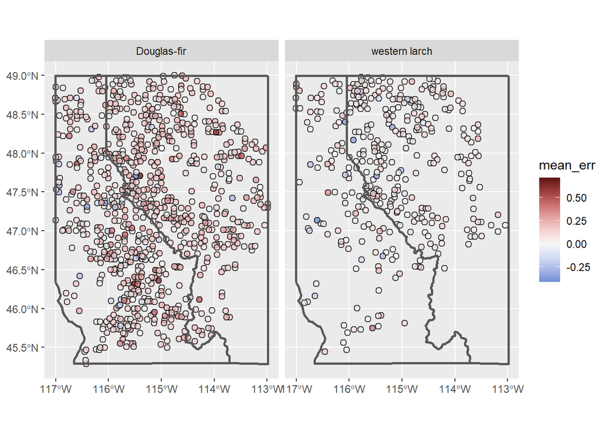

```r
err_map <- ggplot()+
  geom_sf(data = stand_err_spat, aes(fill = mean_err), size = 2,
          pch = 21, stroke = 0.75, alpha = 0.75)+
  geom_sf(data = st_crop(study_region, st_bbox(stand_err_spat)), fill = NA, lwd = 1)+
  scale_fill_continuous_diverging(palette = 'Blue-Red 3', mid = 0)+
  facet_wrap(facets = vars(species_name))+
  coord_sf()+
  theme_grey()
err_map
```

Figure 1: Map of mean stand basal area increment prediction error for Douglas-fir (left) and western larch (right). Lighter colors are errors near 0, reds are overestimates (positive prediction error), and blues are underestimates (negative prediction error).

The few plots with extremely large errors make it harder to see patterns, so I also mapped errors without extreme values as well.

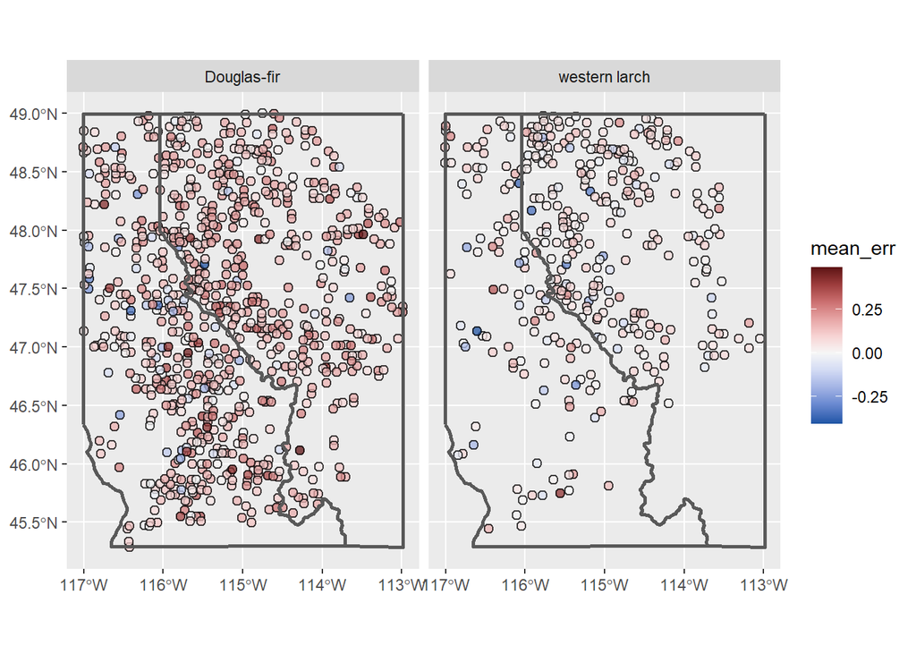

```r
err_map_cens <- stand_err_spat |>
  filter(mean_err <= 0.5, mean_err >= -0.5) |>
ggplot()+
    geom_sf(aes(fill = mean_err), size = 2,
          pch = 21, stroke = 0.75, alpha = 0.75)+
  geom_sf(data = st_crop(study_region, st_bbox(stand_err_spat)), fill = NA, lwd = 1)+
  scale_fill_continuous_diverging(palette = 'Blue-Red 3', mid = 0)+
  facet_wrap(facets = vars(species_name))+
  coord_sf()+
  theme_grey()
err_map_cens
```

Figure 2: Map of mean stand basal area increment prediction error for Douglas-fir (left) and western larch (right). Lighter colors are errors near 0, reds are overestimates (positive prediction error), and blues are underestimates (negative prediction error). Errors have been truncated from -0.5 to +0.5 for ease of visualization.

In addition to examining error patterns over space, I modeled and visualized prediction error by longitude and latitude. I used linear models to explore the relationships between error and longitude, converting longitude into distance (in 100s of km) from 117$^\circ$ W so that the coefficient on longitude represents the effect of moving 100km eastward. Similarly, I converted latitude into distance (in 100s of km) from 45$^\circ$N. I specified the models such that both the intercept and the slope vary by species, such that Douglas-fir and western larch were allowed to have different prediction error patterns over space.

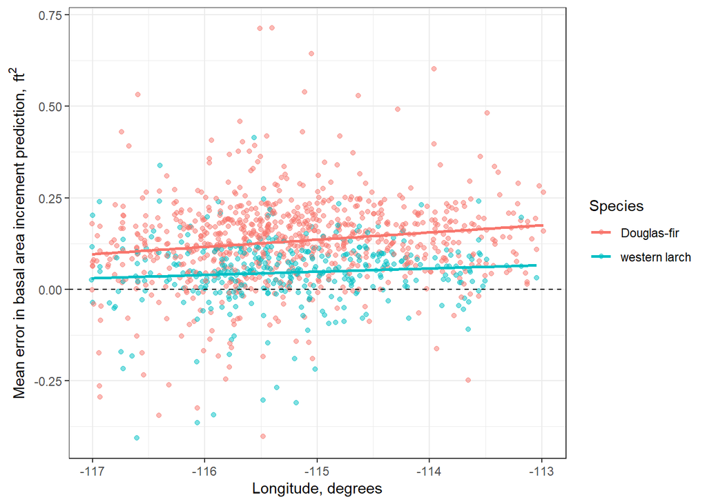

```r
err_lon <- ggplot(stand_err, aes(x = LONGITUDE, y = mean_err, col = species_name))+
  geom_point(alpha = 0.5)+
  geom_smooth(method = 'lm', se = FALSE)+
  geom_hline(yintercept = 0, col = 'black', lty = 'dashed')+
  labs(x = 'Longitude, degrees',
       y = expr(paste('Mean error in basal area increment prediction, ', 'ft'^2)),
       col = 'Species')+
  theme_bw()

err_lon
```

Figure 3: Mean stand-level basal area increment prediction error increases with longitude (i.e., west-to-east movement), but the effect size varies by species. Pink is Douglas-fir, blue is western larch.

Table 1: Results from linear model for error as a function of distance (in 100s of km), with both slope and intercept allowed to vary by species.

```r
# LM
compare_lons <- stand_err |>
  mutate(LONGITUDE = -117) |>
  st_as_sf(coords = c('LONGITUDE', 'LATITUDE'),
           crs = st_crs(stand_locs))

stand_err_spat <- stand_err_spat |>
  # divide by 1000 to get km from m, divide again by 100 to get 100s of km
  mutate(lon_dist = as.numeric(st_distance(compare_lons, geometry, by_element = TRUE))/100000)

lon_lm <- lm(mean_err ~ lon_dist+factor(species_name)+lon_dist*factor(species_name),
             data = stand_err_spat)


# R codes douglas-fir as the "base", then larch is an adjustment on top
```

```
#> of that.
```

```r
data.frame(Coefficient = c('Douglas-fir intercept',
                           'Douglas-fir slope',
                           'Larch intercept',
                           'Larch slope'),
           Estimate = c(unname(coef(lon_lm))[1:2],
                        unname(coef(lon_lm)[1])+unname(coef(lon_lm)[3]),
                        unname(coef(lon_lm)[2])+unname(coef(lon_lm)[4])),
           Standard_error = unname(summary(lon_lm)$coefficients[,2])) |>
  mutate(Estimate = round(Estimate, 4))
```

| Coefficient | Estimate | Standard_error |
| --- | --- | --- |
| Douglas-fir intercept | 0.0959 | 0.0085099 |
| Douglas-fir slope | 0.0263 | 0.0055968 |
| Larch intercept | 0.0304 | 0.0156417 |
| Larch slope | 0.0118 | 0.0105595 |

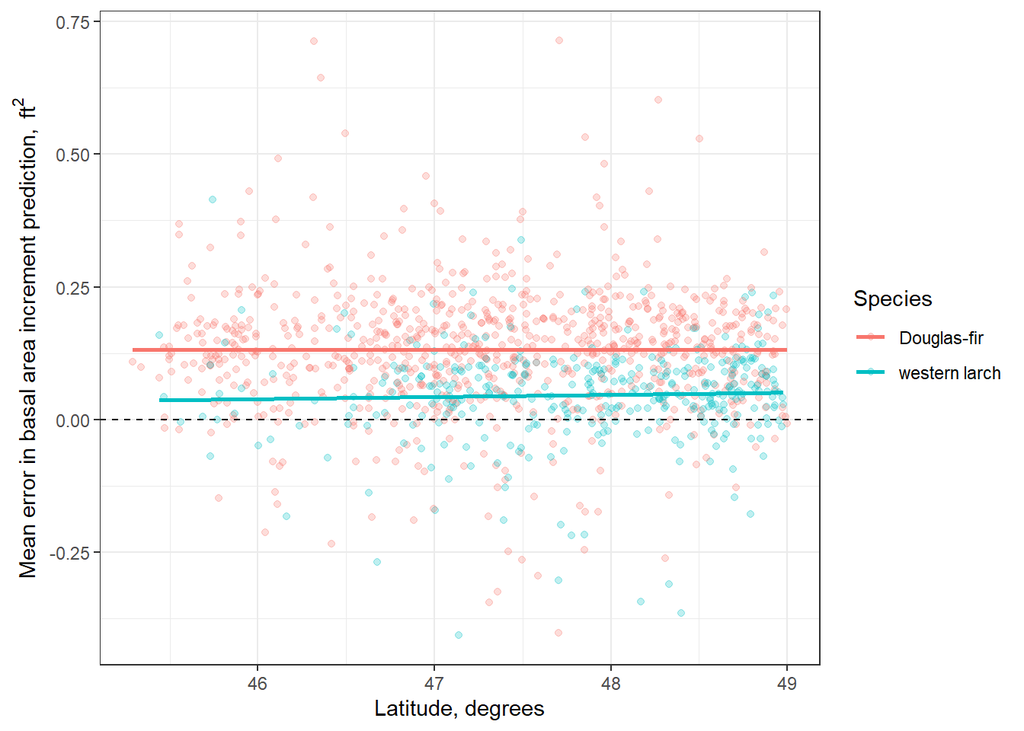

```r
err_lat <- ggplot(stand_err, aes(x = LATITUDE, y = mean_err, col = species_name))+
  geom_point(alpha = 0.25)+
  geom_smooth(method = 'lm', se = FALSE)+
  geom_hline(yintercept = 0, col = 'black', lty = 'dashed')+
  labs(x = 'Latitude, degrees',
       y = expr(paste('Mean error in basal area increment prediction, ', 'ft'^2)),
       col = 'Species')+
  theme_bw()
compare_lats <- stand_err |>
  mutate(LATITUDE = 45) |>
  st_as_sf(coords = c('LONGITUDE', 'LATITUDE'),
           crs = st_crs(stand_locs))

err_lat
```

Figure 4: Mean stand-level basal area increment prediction error does not noticeably change with latitude (south to north). Pink is Douglas-fir, blue is western larch.

Table 2: Results from linear model for error as a function of north/south distance (in 100s of km), with both slope and intercept allowed to vary by species.

```r
stand_err_spat <- stand_err_spat |>
  mutate(lat_dist = as.numeric(st_distance(compare_lats, geometry, by_element = TRUE))/100000)

lat_lm <- lm(mean_err ~ lat_dist+factor(species_name)+lat_dist*factor(species_name),
             data = stand_err_spat)

# R codes douglas-fir as the "base", then larch is an adjustment on top
```

```
#> of that.
```

```r
data.frame(Coefficient = c('Douglas-fir intercept',
                           'Douglas-fir slope',
                           'Larch intercept',
                           'Larch slope'),
           Estimate = c(unname(coef(lat_lm))[1:2],
                        unname(coef(lat_lm)[1])+unname(coef(lat_lm)[3]),
                        unname(coef(lat_lm)[2])+unname(coef(lat_lm)[4])),
           Standard_error = unname(summary(lat_lm)$coefficients[,2])) |>
  mutate(Estimate = round(Estimate, 4))
```

| Coefficient | Estimate | Standard_error |
| --- | --- | --- |
| Douglas-fir intercept | 0.1316 | 0.0104339 |
| Douglas-fir slope | -0.0001 | 0.0037347 |
| Larch intercept | 0.0344 | 0.0232534 |
| Larch slope | 0.0037 | 0.0073589 |

Finally, I examined the relationship between error and climatic water balance.

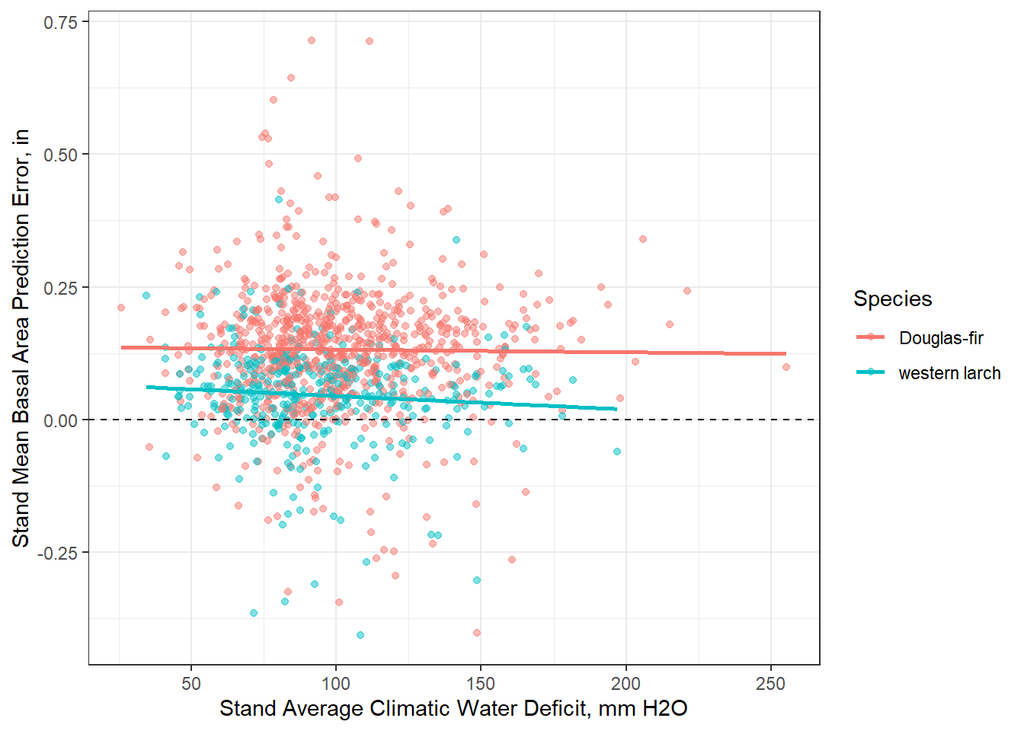

```r
stand_err <- stand_err |>
  left_join(stand_deficits[c('PID', 'deficit')])
err_cwd <-  ggplot(stand_err, aes(x = deficit, y = mean_err, col = species_name))+
  geom_point(alpha = 0.5)+
  labs(x = 'Stand Average Climatic Water Deficit, mm H2O',
       y = 'Stand Mean Basal Area Prediction Error, in',
       col = 'Species')+
  geom_smooth(se = FALSE, method = 'lm')+
  geom_hline(yintercept = 0, lty = 'dashed')+
  theme_bw()

err_cwd
```

Figure 5: Mean stand-level basal area increment prediction error does not noticeably change with climatic water deficit, a measure of drought stress. Pink is Douglas-fir, blue is western larch.

Table 3: Results from linear model for prediction error in basal area increment by climatic water deficit, with both slope and intercept allowed to vary by species. There was no detectable relationship for either species.

```r
cwd_lm <- lm(mean_err ~ deficit+factor(species_name)+deficit*factor(species_name),
             data = stand_err)

# R codes douglas-fir as the "base", then larch is an adjustment on top
```

```
#> of that.
```

```r
data.frame(Coefficient = c('Douglas-fir intercept',
                           'Douglas-fir slope',
                           'Larch intercept',
                           'Larch slope'),
           Estimate = c(unname(coef(cwd_lm))[1:2],
                        unname(coef(cwd_lm)[1])+unname(coef(cwd_lm)[3]),
                        unname(coef(cwd_lm)[2])+unname(coef(cwd_lm)[4])),
           Standard_error = unname(summary(cwd_lm)$coefficients[,2])) |>
  mutate(Estimate = round(Estimate, 4))
```

| Coefficient | Estimate | Standard_error |
| --- | --- | --- |
| Douglas-fir intercept | 0.1372 | 0.0141427 |
| Douglas-fir slope | -0.0001 | 0.0001341 |
| Larch intercept | 0.0698 | 0.0243541 |
| Larch slope | -0.0003 | 0.0002422 |

## Conclusions

Generally, FVS overestimated basal area increment. These predictions errors were generally worse for Douglas-fir than western larch, but there were not clear spatial patterns when mapping the entire region (Figure 1). However, examining results on solely the longitude and solely the latitude axis provided more insight. The longitudinal gradient in basal area prediction error (Figure 3; Table 1) and undetectable effect of latitude (Figure 4; Table 2) suggest that orographic effects from the north/south running Bitterroot range could be adding to the need for FVS calibration; FVS performs better west of the Bitterroots. These results are consistent with my prediction 1, supporting my hypothesis that FVS-IE is unable to account for differences in growth driven by local-scale climate variation. However, prediction errors appear heteroskedastic with respect to longitude: they are more variable in western stands than eastern stands. Thus, the simple linear model results may be biased and further exploration is needed.

Contrary to my second prediction, climatic water deficit had no detectable relationship with prediction error (Figure 5; Table 3). That is, FVS predicted basal area just as accurately for more drought-stressed plots than less drought-stressed plots. This suggests that drought stress is not one of the “undetectable local variables” discussed earlier. These results, combined with the findings of a longitudinal relationship, suggest that climate variables with more west-to-east variation could be more important than deficit in this context.

## System Info

```r
Sys.info()
```

```
          sysname           release           version          nodename
        "Windows"          "10 x64"     "build 26200" "CFCAFFLECK1-D25"
          machine             login              user    effective_user
         "x86-64"        "sp258446"        "sp258446"        "sp258446"
          udomain
       "MISSOULA"
```

## References

*ARB Compliance Offset Program: U.s. Forest Offset Protocol Frequently Asked Questions*. 2013. https://ww2.arb.ca.gov/sites/default/files/cap-and-trade/protocols/usforest/resources/faq_102913_post.pdf.

Crookston, Nicholas L., and Gary E. Dixon. 2005. “The Forest Vegetation Simulator: A Review of Its Structure, Content, and Applications.” *Computers and Electronics in Agriculture* 49 (1): 60–80. https://doi.org/10.1016/j.compag.2005.02.003.

Diaz, David D., Sara Loreno, Gregory J. Ettl, and Brent Davies. 2018. “Tradeoffs in Timber, Carbon, and Cash Flow Under Alternative Management Systems for Douglas-Fir in the Pacific Northwest.” *Forests* 9 (8): 447. https://doi.org/10.3390/f9080447.

Dixon, Gary E. 2002. *Essential FVS: A User’s Guide to the Forest Vegetation Simulator*. Fort Collins, CO. https://www.fs.usda.gov/sites/default/files/forest-management/essential-fvs.pdf.

Ex, Seth A., and Frederick W. Smith. 2014. “Evaluating Forest Vegetation Simulator Performance for Trees in Multiaged Ponderosa Pine Stands, Black Hills, USA.” *Forest Science* 60 (2): 214–21. https://doi.org/10.5849/forsci.12-054.

Gorain, Subrata, Suman Dutta, Sumana Balo, Ayushman Malakar, Malini Roy Choudhury, and Sumanta Das. 2025. “Harnessing Green Wealth: A Two-Decade Global Assessment of Forest Carbon Sequestration and Credits and the Economic Implications of Sustainable Forest Management Practices.” *Journal of Environmental Management* 393 (October): 126987. https://doi.org/10.1016/j.jenvman.2025.126987.

Herbert, Claudia, Jeremy S. Fried, and Van Butsic. 2023. “Validation of Forest Vegetation Simulator Model Finds Overprediction of Carbon Growth in California.” *Forests* 14 (3): 604. https://doi.org/10.3390/f14030604.

Hijmans, Robert J. 2025. *Terra: Spatial Data Analysis*. https://doi.org/10.32614/CRAN.package.terra.

Joo, Sukhyun, Hailemariam Temesgen, Bryce Frank, Aaron R. Weiskittel, and Don Reimer. 2025. “Roles of Growth and Yield Models for Informed Forest Management Decisions in the Pacific Northwest United States.” *J. For.* 123 (5): 593–627. https://doi.org/10.1007/s44392-025-00041-0.

Marvin, David C., Benjamin M. Sleeter, D. Richard Cameron, Erik Nelson, and Andrew J. Plantinga. 2023. “Natural Climate Solutions Provide Robust Carbon Mitigation Capacity Under Future Climate Change Scenarios.” *Scientific Reports* 13 (1): 19008. https://doi.org/10.1038/s41598-023-43118-6.

Massicotte, Philippe, and Andy South. 2025. *Rnaturalearth: World Map Data from Natural Earth*. https://doi.org/10.32614/CRAN.package.rnaturalearth.

Munro, Holly L., Christopher W. Woodall, William R. L. Anderegg, et al. 2025. “Challenges and Strategic Recommendations for Enhancing Quantification and Projection of Forest Carbon Dynamics.” *Journal of Forestry*, ahead of print, August 29. https://doi.org/10.1007/s44392-025-00048-7.

Pebesma, E. 2018. “Simple Features for r: Standardized Support for Spatial Vector Data.” *The R Journal* 10 (1): 439–46. https://doi.org/https://doi.org/10.32614/RJ-2018-009.

Pedersen, Thomas L. 2025. *Patchwork: The Composer of Plots*. https://doi.org/10.32614/CRAN.package.patchwork.

Smyth, C. E., G. Stinson, E. Neilson, et al. 2014. “Quantifying the Biophysical Climate Change Mitigation Potential of Canada’s Forest Sector.” *Biogeosciences* 11 (13): 3515–29. https://doi.org/10.5194/bg-11-3515-2014.

Stage, Albert R. 1973. *Prognosis Model for Stand Development*. Ogden, UT.

Tercek, Michael T., David P. Thoma, John E. Gross, and Kirk Sherrill. 2021. *Gridded Water Balance Model*.

Weiskittel, Aaron R., David W. Hann, John A. Kershaw, and Jerome K. Vanclay. 2011. *Forest Growth and Yield Modeling*. August 3. https://doi.org/10.1002/9781119998518.

Wickham, Hadley. 2016. *Ggplot2: Elegant Graphics for Data Analysis*. 2nd ed. Use r! Springer International Publishing. https://doi.org/10.1007/978-3-319-24277-4.

Wickham, Hadley, Romain François, Lionel Henry, Kirill Müller, and Davis Vaughan. 2023. *Dplyr: A Grammar of Data Manipulation*. https://doi.org/10.32614/CRAN.package.dplyr.

Wykoff, William R. 1990. “A Basal Area Increment Model for Individual Conifers in the Northern Rocky Mountains.” *Forest Science* 36 (4): 1077–104. https://doi.org/10.1093/forestscience/36.4.1077.